# Projekt 2

Antoni Zawodny, Tomasz Gałązka

17 grudnia 2016

##### Projekt dotyczy rozpoznania wzorców strategii według których uczniowie rozwiązują zadania na egzaminie. Dostarczone dane pochodzą z badań PISA z 2016 roku. Struktura wygląda następująco (czas rozwiązywania zadań został przedstawiony w minutach):

```r
library("dplyr")
library("tidyr")
library("ggplot2")
load("D:/RStudio/projekt2/onlyTimingsLong.rda")

onlyTimingsLong$Czas<-onlyTimingsLong$Czas/1000/60
head(onlyTimingsLong)
```

```
##            Kraj  Szkola Student Zestaw      Czas Zadanie Pozycja Obszar
## 10737 Australia 3600001 3601769     31  3.259200 R219Q01       3      R
## 10742 Australia 3600001 3605983     85  2.389233 R219Q01       2      R
## 10747 Australia 3600001 3602143     36  3.446917 R219Q01       4      R
## 10759 Australia 3600002 3611016     37  1.955867 R219Q01       1      R
## 10787 Australia 3600003 3605314     36  2.915917 R219Q01       4      R
## 10794 Australia 3600003 3611875     41 21.162917 R219Q01       2      R
```

##### Otrzymane dane wymagają oczyszczenia. Niektóre czasy rozwiązywania testu znacznie przekraczają 2 godziny, a kolumna “pozycja” jest w części przypadków wypełniona niezgodnie z przyjętym formatem.

```r
summary(onlyTimingsLong$Czas)
```

```
##     Min.  1st Qu.   Median     Mean  3rd Qu.     Max.
##   0.0024   0.5973   1.1170   1.4510   1.8980 734.0000
```

```r
summary(onlyTimingsLong$Pozycja)
```

```
##    Min. 1st Qu.  Median    Mean 3rd Qu.    Max.
##  -1.000   1.000   3.000   2.485   3.000   4.000
```

```r
stat2 <- onlyTimingsLong %>% dplyr::group_by(Student) %>% dplyr::summarise(sum(Czas))

zli<-as.matrix(stat2[which(stat2$`sum(Czas)`>120),1])

Dane <- onlyTimingsLong[-which(onlyTimingsLong$Pozycja=="-1"),]
Dane <- Dane[!Dane$Student %in% zli,]


stat_szkola <- as.data.frame(table(Dane$Szkola))
zli_szkola<-as.matrix(stat_szkola[which(stat_szkola$Freq<100),1])
Dane <- Dane[!Dane$Szkola %in% zli_szkola,]


Dane[Dane$Kraj=='Spain (Regions)',]$Kraj <- 'Spain'
Dane[Dane$Kraj=='Massachusettes (USA)',]$Kraj <- 'United States'
Dane[Dane$Kraj=='North Carolina (USA)',]$Kraj <- 'United States'
Dane[Dane$Kraj=='B-S-J-G (China)',]$Kraj <- 'China'
Dane$Kraj <- droplevels(Dane$Kraj)

stat <- Dane %>% dplyr::group_by(Kraj) %>% dplyr::summarise(mean(Czas))
stat <- as.matrix(stat)

rm(stat_szkola, stat2, zli_szkola, onlyTimingsLong,zli)
```

##### Usuwamy skrajne dane przy pomocy funkcji boxplot.stats()$out (ponad 400 tys.).

```r
Dane_kraj <- Dane[which(Dane$Kraj==stat[1,1]),]
Danep<-Dane_kraj[!Dane_kraj$Czas %in% boxplot.stats(Dane_kraj$Czas)$out,]

for (i in 2:55){
  Dane_kraj <- Dane[which(Dane$Kraj==stat[i,1]),]
  maska <- Dane_kraj[!Dane_kraj$Czas %in% boxplot.stats(Dane_kraj$Czas)$out,]
  Danep <- rbind(Danep,maska)
}

rm(maska,Dane,i, Dane_kraj)
```

##### Poniższy histogram przedstawia rozkład długości rozwiązywania pojedynczego zadania.

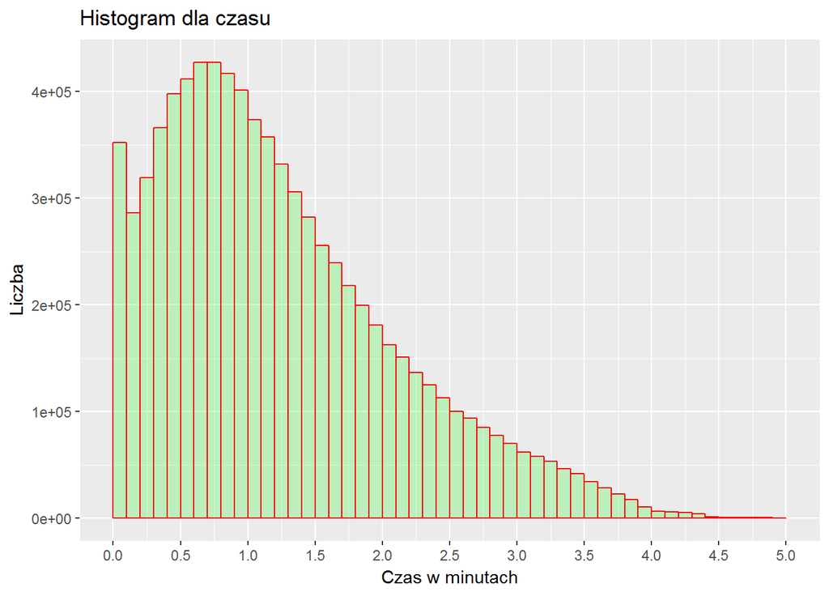

```r
ggplot(data=Danep, aes(Danep$Czas)) +
  geom_histogram(breaks=seq(0, 5, by = .1),
                 col="red",
                 fill="green",
                 alpha = .2) +
  labs(title="Histogram dla czasu") +
  labs(x="Czas w minutach", y="Liczba") + scale_x_continuous(breaks=scales::pretty_breaks(n = 10))
```

##### Poniżej zamieszczamy czas rozwiązywania zadań dla poszczególnych krajów z części matematycznej i z czytania.

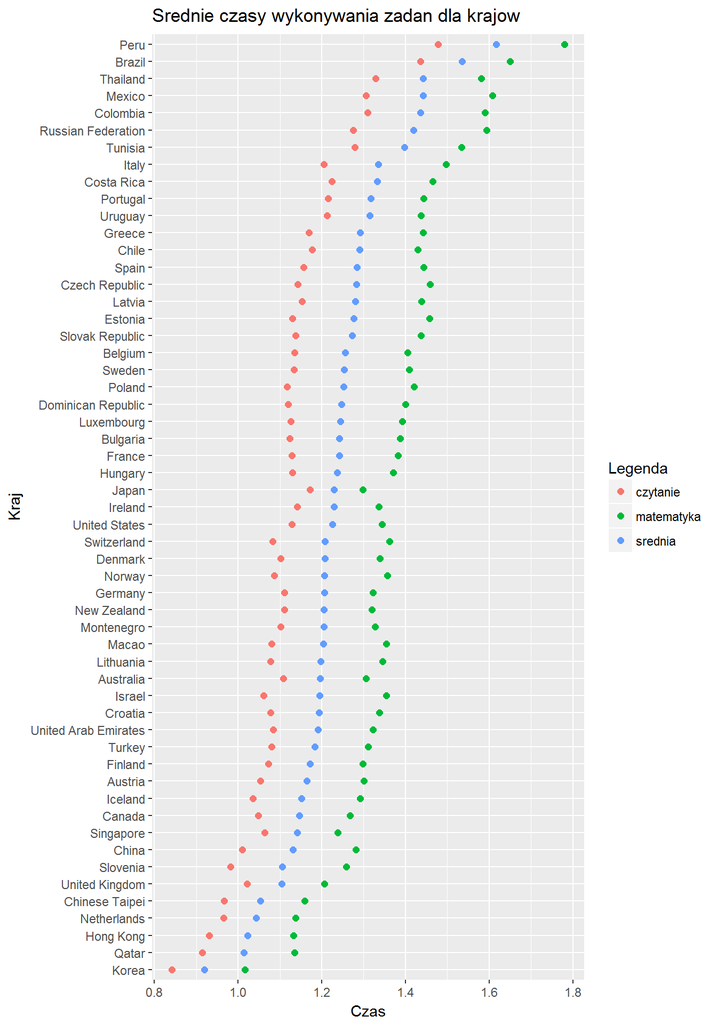

```r
Dane_math<-Danep[Danep$Obszar=='M',]
Dane_read<-Danep[Danep$Obszar=='R',]

stat_math <- Dane_math %>% dplyr::group_by(Kraj)  %>% dplyr::summarise(mean(Czas))
stat_read <- Dane_read %>% dplyr::group_by(Kraj)  %>% dplyr::summarise(mean(Czas))
stat<- Danep %>% dplyr::group_by(Kraj) %>% dplyr::summarise(mean(Czas))
statystyki<- cbind(stat_math[,1], stat_math$`mean(Czas)`, stat_read$`mean(Czas)`, stat$`mean(Czas)`)
colnames(statystyki) <- c('Kraj', 'M', 'R', 'mean')

statystyki$Kraj<-factor(statystyki$Kraj, levels = statystyki$Kraj[order(statystyki$mean)])

ggplot() +
geom_point(data=statystyki, aes(x=Kraj, y=R, color='czytanie'), size=2) +
geom_point(data=statystyki, aes(x=Kraj, y=M, color='matematyka'), size=2) +
geom_point(data=statystyki, aes(x=Kraj, y=mean, color='srednia'), size=2) +
labs(title='Srednie czasy wykonywania zadan dla krajow', y='Czas', x='Kraj', color='Legenda')+
coord_flip()
```

```r
rm(stat_math, stat_read, stat, statystyki)
```

##### Wykresy przedstawiające rozkład długości czasu rozwiązywania zadania w każdym z 4 obszarów z zadań matematycznych i z czytania.

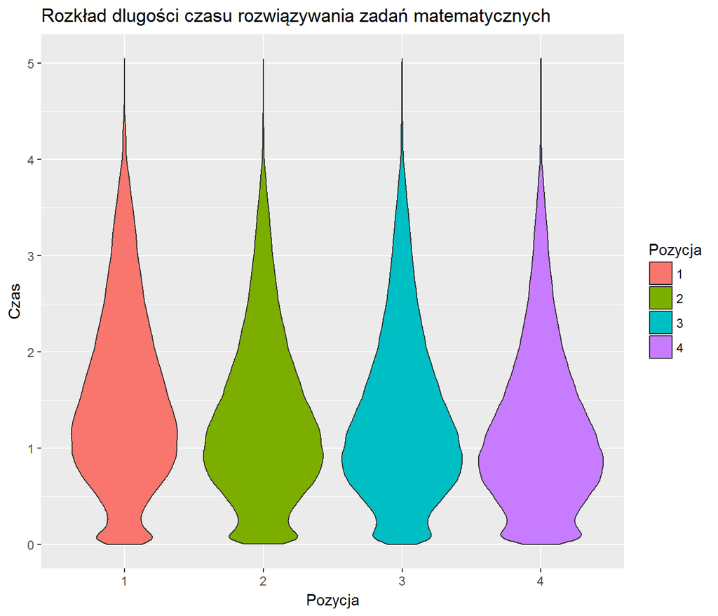

```r
Dane_math1 <- Dane_math[Dane_math$Pozycja == 1,]
Dane_math2 <- Dane_math[Dane_math$Pozycja == 2,]
Dane_math3 <- Dane_math[Dane_math$Pozycja == 3,]
Dane_math4 <- Dane_math[Dane_math$Pozycja == 4,]

Dane_read1 <- Dane_read[Dane_read$Pozycja == 1,]
Dane_read2 <- Dane_read[Dane_read$Pozycja == 2,]
Dane_read3 <- Dane_read[Dane_read$Pozycja == 3,]
Dane_read4 <- Dane_read[Dane_read$Pozycja == 4,]


ggplot(Dane_math, aes(x = as.character(Pozycja) , y = Czas, fill=as.character(Pozycja))) +
labs(title="Rozkład dlugości czasu rozwiązywania zadań matematycznych ",x="Pozycja", y = "Czas", fill="Pozycja") +
geom_violin()
```

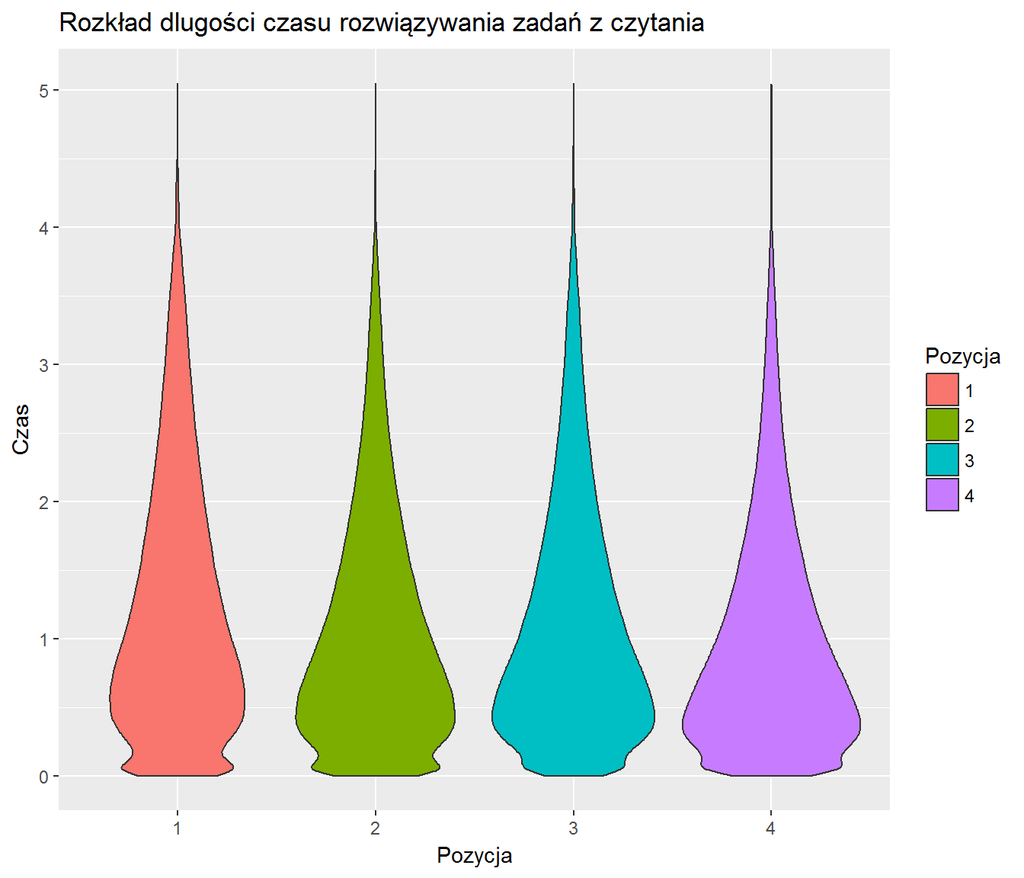

```r
ggplot(Dane_read, aes(x = as.character(Pozycja) , y = Czas, fill=as.character(Pozycja))) +
labs(title="Rozkład dlugości czasu rozwiązywania zadań z czytania ",x="Pozycja", y = "Czas", fill="Pozycja") +
geom_violin()
```

```r
rm(Dane_math, Dane_read)
```

##### Po powyższych wykresach stwierdzamy, że zadania z czytania są rozwiązywane szybciej niż zadania z matematyki. Ponadto widać, że najwolniej rozwiązywane są zadania z pierwszej części egzaminu, co najprawdopodobniej wynika z tego, że uczniowie dopiero zapoznają się ze strukturą egzaminu. Część ostatnia przebiega najszybciej, bo uczniowie są pod presją czasu ze względu na bliski koniec egzaminu, a ponadto są już zaznajomieni z formułą. Część trzecia przebiega minimalnie wolniej niż druga, co wynika najprawdopodobniej z tego, że studenci są rozluźnieni przerwą między drugą, a trzecią częścią egzaminu. Rozkłady długości czasu rozwiązywania zadań przypominają rozkłady normalne nie uwzględniając tego, że jest sporo bardzo krótkich czasów rozwiązywania. Przyczyną tego jest najprawdopodobniej odruchowe i impulsywne klikanie na odpowiedź po wyświetleniu pytania.

##### 2. Etap

##### Celem drugiego etapu było wyznaczenie pewnych wzorców którymi kierują się studenci w trakcie rozwiązywania testu PISA jeśli chodzi o długość rozwiązywania zadań. Niestety studentów jest ponad 35 tysięcy a nie mamy dostępu do żadnych bezpłatnych mainframe’ów, dlatego też zamiast badać to w jaki sposób studenci postępują zajęliśmy się spojrzeniem na to jak studenci danych szkół radzą sobie z testami.

##### W pierwszym podejściu postanowiliśmy użyć grupowania przy pomocy następującej metryki - dla każdego z zadań, które rozwiązywała dana szkoła liczymy średni czas jaki był potrzebny na rozwiązanie, a następnie sumujemy różnice tych średnich czasów dla obu szkół. Przy pierwszym podejściu rzutujemy liniowo wektor średnich na przestrzeń dwuwymiarową próbując zachowywać odległości. Przykład działania na kilku krajach widać następująco:

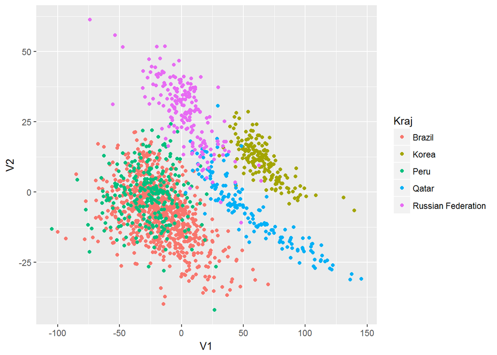

```r
srednie_wybrane <-Danep[Danep$Kraj %in% c('Korea','Peru', 'Russian Federation', 'Brazil', 'Qatar'),] %>% dplyr::group_by(Kraj,Szkola,Zadanie) %>% dplyr::summarise(mean(Czas)) %>%  spread(Zadanie, 'mean(Czas)')

srednie<-apply(srednie_wybrane[,-c(1,2)], 2, function(x){mean(x, na.rm = TRUE)})
for (i in 1:nrow(srednie_wybrane)) {
  srednie_wybrane[i,-c(1,2)][is.na(srednie_wybrane[i,-c(1,2)])]<-srednie[is.na(srednie_wybrane[i,-c(1,2)])]
}

odl_wybrane<-dist(srednie_wybrane[,-c(1,2)], method='manhattan')

cmd<-as.data.frame(cmdscale(odl_wybrane))
cmd$Kraj<-srednie_wybrane$Kraj
ggplot(cmd, aes(x=V1, y=V2, color=Kraj))+geom_point()
```

```r
rm(cmd, srednie_wybrane, i, odl_wybrane, srednie)
```

##### Patrząc na powyższy wykres stwierdziliśmy, że nie chcemy rzutować na przestrzeń niższego wymiaru, bowiem tracimy przy tym bardzo dużą ilość informacji. Postanowiliśmy więc wyliczać odległości między szkołami bez rzutowania. Widzimy jednak, ze przykladowo dla Korei odleglosci miedzy szkolami sa bardzo male, co sugeruje, ze wszystkie szkoly rozwiazuja testy podobnie.

##### Będziemy przeprowadzać hierarchiczny podział szkół na grupy w podejściu *bottom up*. Odległość między parą szkół definiujemy w następujący sposób. Dla każdej ze szkół liczymy 8 średnich czasów rozwiązywania zadań:

- zadania matematyczne z 1. części egzaminu,
- zadania matematyczne z 2. części egzaminu,
- zadania matematyczne z 3. części egzaminu,
- zadania matematyczne z 4. części egzaminu,
- zadania z czytania z 1. części egzaminu,
- zadania z czytania z 2. części egzaminu,
- zadania z czytania z 3. części egzaminu,
- zadania z czytania z 4. części egzaminu,

##### a odległość między szkołami określamy jako sumę modułów różnic odpowiadających sobie średnich czasów. Uznaliśmy, że jest to metryka, która będzie dobrze odróżniała strategie szkół bowiem uwzględniamy wszystkie możliwe konfiguracje pozycji i obszaru w danych, a właśnie o to chodziło w zadaniu. W kwestii łączenia grup w większe wybraliśmy metodę *complete*.

```r
srednie_math1 <- Dane_math1 %>% dplyr::group_by(Kraj,Szkola,Zadanie) %>% dplyr::summarise(mean(Czas)) %>%  spread(Zadanie, 'mean(Czas)')

srednie<-apply(srednie_math1[,-c(1,2)], 2, function(x){mean(x, na.rm = TRUE)})
for (i in 1:nrow(srednie_math1)) {
  srednie_math1[i,-c(1,2)][is.na(srednie_math1[i,-c(1,2)])]<-srednie[is.na(srednie_math1[i,-c(1,2)])]
}

srednie_math2 <- Dane_math2 %>% dplyr::group_by(Kraj,Szkola,Zadanie) %>% dplyr::summarise(mean(Czas)) %>%  spread(Zadanie, 'mean(Czas)')

srednie<-apply(srednie_math2[,-c(1,2)], 2, function(x){mean(x, na.rm = TRUE)})
for (i in 1:nrow(srednie_math2)) {
  srednie_math2[i,-c(1,2)][is.na(srednie_math2[i,-c(1,2)])]<-srednie[is.na(srednie_math2[i,-c(1,2)])]
}

srednie_math3 <- Dane_math3 %>% dplyr::group_by(Kraj,Szkola,Zadanie) %>% dplyr::summarise(mean(Czas)) %>%  spread(Zadanie, 'mean(Czas)')

srednie<-apply(srednie_math3[,-c(1,2)], 2, function(x){mean(x, na.rm = TRUE)})
for (i in 1:nrow(srednie_math3)) {
  srednie_math3[i,-c(1,2)][is.na(srednie_math3[i,-c(1,2)])]<-srednie[is.na(srednie_math3[i,-c(1,2)])]
}

srednie_math4 <- Dane_math4 %>% dplyr::group_by(Kraj,Szkola,Zadanie) %>% dplyr::summarise(mean(Czas)) %>%  spread(Zadanie, 'mean(Czas)')

srednie<-apply(srednie_math4[,-c(1,2)], 2, function(x){mean(x, na.rm = TRUE)})
for (i in 1:nrow(srednie_math4)) {
  srednie_math4[i,-c(1,2)][is.na(srednie_math4[i,-c(1,2)])]<-srednie[is.na(srednie_math4[i,-c(1,2)])]
}

srednie_read1 <- Dane_read1 %>% dplyr::group_by(Kraj,Szkola,Zadanie) %>% dplyr::summarise(mean(Czas)) %>%  spread(Zadanie, 'mean(Czas)')

srednie<-apply(srednie_read1[,-c(1,2)], 2, function(x){mean(x, na.rm = TRUE)})
for (i in 1:nrow(srednie_read1)) {
  srednie_read1[i,-c(1,2)][is.na(srednie_read1[i,-c(1,2)])]<-srednie[is.na(srednie_read1[i,-c(1,2)])]
}

srednie_read2 <- Dane_read2 %>% dplyr::group_by(Kraj,Szkola,Zadanie) %>% dplyr::summarise(mean(Czas)) %>%  spread(Zadanie, 'mean(Czas)')

srednie<-apply(srednie_read2[,-c(1,2)], 2, function(x){mean(x, na.rm = TRUE)})
for (i in 1:nrow(srednie_read2)) {
  srednie_read2[i,-c(1,2)][is.na(srednie_read2[i,-c(1,2)])]<-srednie[is.na(srednie_read2[i,-c(1,2)])]
}

srednie_read3 <- Dane_read3 %>% dplyr::group_by(Kraj,Szkola,Zadanie) %>% dplyr::summarise(mean(Czas)) %>%  spread(Zadanie, 'mean(Czas)')

srednie<-apply(srednie_read3[,-c(1,2)], 2, function(x){mean(x, na.rm = TRUE)})
for (i in 1:nrow(srednie_read3)) {
  srednie_read3[i,-c(1,2)][is.na(srednie_read3[i,-c(1,2)])]<-srednie[is.na(srednie_read3[i,-c(1,2)])]
}

srednie_read4 <- Dane_read4 %>% dplyr::group_by(Kraj,Szkola,Zadanie) %>% dplyr::summarise(mean(Czas)) %>%  spread(Zadanie, 'mean(Czas)')

srednie<-apply(srednie_read4[,-c(1,2)], 2, function(x){mean(x, na.rm = TRUE)})
for (i in 1:nrow(srednie_read4)) {
  srednie_read4[i,-c(1,2)][is.na(srednie_read4[i,-c(1,2)])]<-srednie[is.na(srednie_read4[i,-c(1,2)])]
}

dobre <- intersect(srednie_math1$Szkola, srednie_math2$Szkola)
dobre <- intersect(dobre, srednie_math3$Szkola)
dobre <- intersect(dobre, srednie_math4$Szkola)
dobre <- intersect(dobre, srednie_read1$Szkola)
dobre <- intersect(dobre, srednie_read2$Szkola)
dobre <- intersect(dobre, srednie_read3$Szkola)
dobre <- intersect(dobre, srednie_read4$Szkola)

srednie_math1 <- srednie_math1[srednie_math1$Szkola %in% dobre,]
srednie_math2 <- srednie_math2[srednie_math2$Szkola %in% dobre,]
srednie_math3 <- srednie_math3[srednie_math3$Szkola %in% dobre,]
srednie_math4 <- srednie_math4[srednie_math4$Szkola %in% dobre,]
srednie_read1 <- srednie_read1[srednie_read1$Szkola %in% dobre,]
srednie_read2 <- srednie_read2[srednie_read2$Szkola %in% dobre,]
srednie_read3 <- srednie_read3[srednie_read3$Szkola %in% dobre,]
srednie_read4 <- srednie_read4[srednie_read4$Szkola %in% dobre,]

rm(i, srednie)
```

```r
odl<-dist(srednie_math1[,-c(1,2)], method='manhattan')
odl<-odl + dist(srednie_math2[,-c(1,2)], method='manhattan')
odl<-odl + dist(srednie_math3[,-c(1,2)], method='manhattan')
odl<-odl + dist(srednie_math4[,-c(1,2)], method='manhattan')
odl<-odl + dist(srednie_read1[,-c(1,2)], method='manhattan')
odl<-odl + dist(srednie_read2[,-c(1,2)], method='manhattan')
odl<-odl + dist(srednie_read3[,-c(1,2)], method='manhattan')
odl<-odl + dist(srednie_read4[,-c(1,2)], method='manhattan')


#save(odl,file="odl.rda")
#load('odl.rda')

klaster <-hclust(odl,method="complete")
```

##### Poniżej znajduje się dendrogram utworzony na podstawie macierzy odległości między szkołami przy pomocy podanej przez nas metryki.

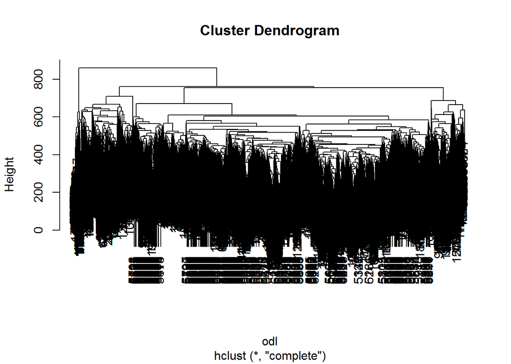

```r
plot(klaster)
```

##### Kierując się postacią dendrogramu uznaliśmy, że podzielimy szkoły na 4 grupy. Dendrogram sugeruje, że grupy te będą się różnić od siebie w widoczny sposób (są od siebie “daleko” według metryki miejskiej). Nie chcieliśmy dzielić szkół na więcej grup bowiem po pierwsze dendrogram nie pokazywał, że będzie to praktyczny podział szkół, a po drugie ciężko byłoby charakteryzować większą liczbę grup, aby każda z nich wyróżniała się czymś unikalnym na tle pozostałych.

```r
klaster_cut <- cutree(klaster,4)


dobre1 <- dobre[which(klaster_cut==1)]
dobre2 <- dobre[which(klaster_cut==2)]
dobre3 <- dobre[which(klaster_cut==3)]
dobre4 <- dobre[which(klaster_cut==4)]


Dane1 <- Danep[Danep$Szkola %in% dobre1,]
Dane1$nr <- 'grupa 1'
Dane2 <- Danep[Danep$Szkola %in% dobre2,]
Dane2$nr <- 'grupa 2'
Dane3 <- Danep[Danep$Szkola %in% dobre3,]
Dane3$nr <- 'grupa 3'
Dane4 <- Danep[Danep$Szkola %in% dobre4,]
Dane4$nr <- 'grupa 4'

Dane <- rbind(Dane1, Dane2, Dane3, Dane4)

Dane_test <- Dane %>% dplyr::group_by(Szkola, nr, Obszar) %>% dplyr::summarise(mean(Czas))

Dane_M <- Dane[Dane$Obszar == 'M',] %>% dplyr::group_by(Szkola, nr) %>% dplyr::summarise(mean(Czas))

Dane_R <- Dane[Dane$Obszar == 'R',] %>% dplyr::group_by(Szkola, nr) %>% dplyr::summarise(mean(Czas))

Dane_P1 <- Dane[Dane$Pozycja == 1,] %>% dplyr::group_by(Szkola, nr) %>% dplyr::summarise(mean(Czas))
Dane_P2 <- Dane[Dane$Pozycja == 2,] %>% dplyr::group_by(Szkola, nr) %>% dplyr::summarise(mean(Czas))
Dane_P3 <- Dane[Dane$Pozycja == 3, ] %>% dplyr::group_by(Szkola, nr) %>% dplyr::summarise(mean(Czas))
Dane_P4 <- Dane[Dane$Pozycja == 4,] %>% dplyr::group_by(Szkola, nr) %>% dplyr::summarise(mean(Czas))

Dane_G1P <- Dane[Dane$nr == 'grupa 1',] %>% dplyr::group_by(Szkola, Pozycja) %>% dplyr::summarise(mean(Czas))
Dane_G2P <- Dane[Dane$nr == 'grupa 2',] %>% dplyr::group_by(Szkola, Pozycja) %>% dplyr::summarise(mean(Czas))
Dane_G3P <- Dane[Dane$nr == 'grupa 3',] %>% dplyr::group_by(Szkola, Pozycja) %>% dplyr::summarise(mean(Czas))
Dane_G4P <- Dane[Dane$nr == 'grupa 4',] %>% dplyr::group_by(Szkola, Pozycja) %>% dplyr::summarise(mean(Czas))
```

##### Analiza

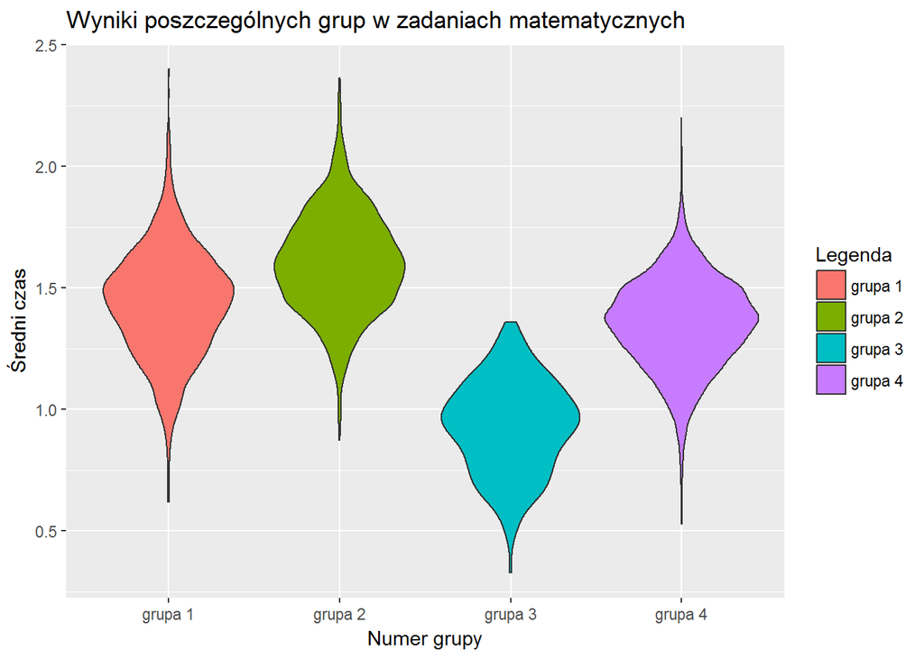

```r
ggplot(Dane_M, aes(x = nr , y = `mean(Czas)`, fill=nr)) + labs(title="Wyniki poszczególnych grup w zadaniach matematycznych",x="Numer grupy", y = "Średni czas", fill="Legenda") + geom_violin()
```

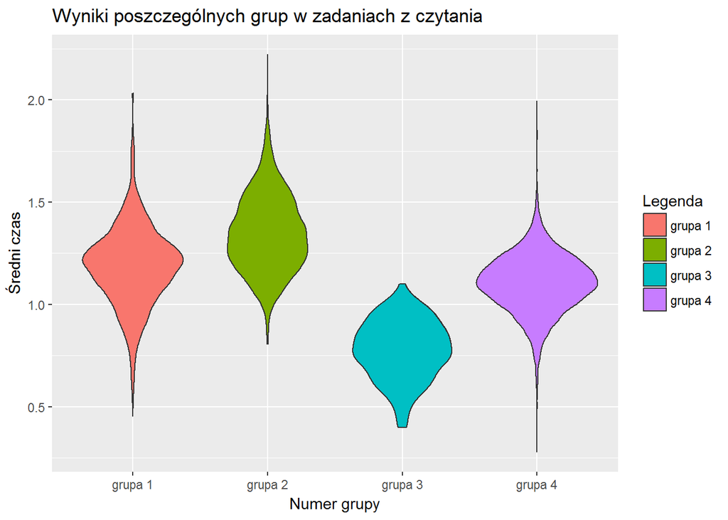

```r
ggplot(Dane_R, aes(x = nr , y = `mean(Czas)`, fill=nr)) + labs(title="Wyniki poszczególnych grup w zadaniach z czytania",x="Numer grupy", y = "Średni czas", fill="Legenda") + geom_violin()
```

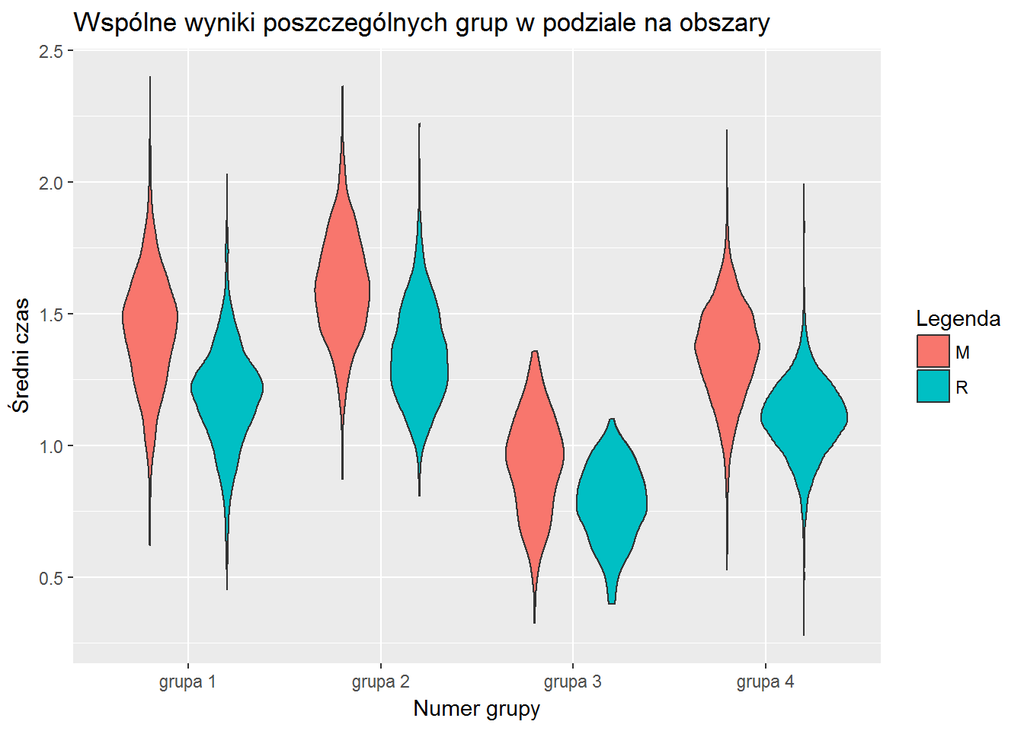

```r
ggplot(Dane_test, aes(x = nr , y = `mean(Czas)`, fill=Obszar)) + labs(title="Wspólne wyniki poszczególnych grup w podziale na obszary",x="Numer grupy", y = "Średni czas", fill='Legenda') + geom_violin( position=position_dodge(0.8))
```

##### Analiza wyników wszystkich grup w poszczególnych częściach testów nie wnosi nic nowego. Dużo więcej wnosi analiza kolejnych grup we wszystkich częściach.

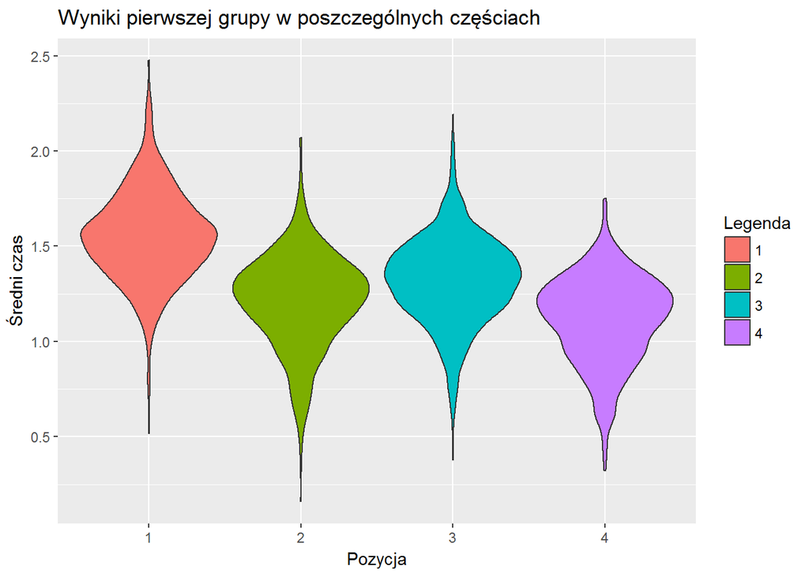

```r
ggplot(Dane_G1P, aes(x = as.character(Pozycja) , y = `mean(Czas)`, fill=as.character(Pozycja))) + labs(title="Wyniki pierwszej grupy w poszczególnych częściach ",x="Pozycja", y = "Średni czas", fill="Legenda") + geom_violin()
```

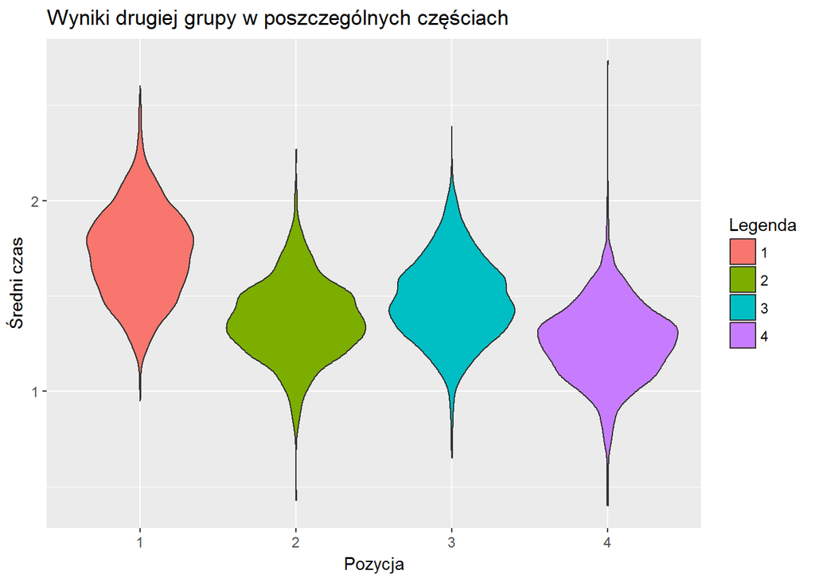

```r
ggplot(Dane_G2P, aes(x = as.character(Pozycja) , y = `mean(Czas)`, fill=as.character(Pozycja))) + labs(title="Wyniki drugiej grupy w poszczególnych częściach ",x="Pozycja", y = "Średni czas", fill="Legenda") + geom_violin()
```

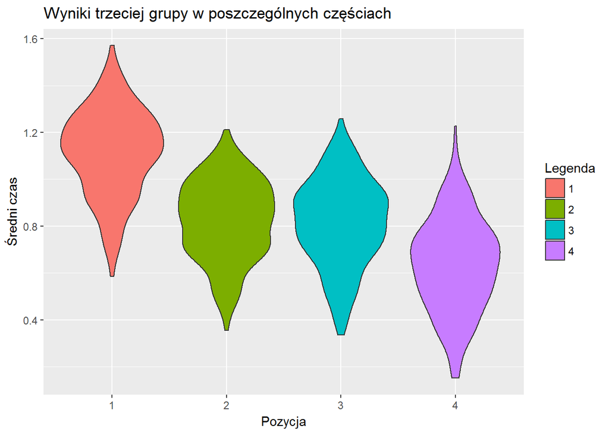

```r
ggplot(Dane_G3P, aes(x = as.character(Pozycja) , y = `mean(Czas)`, fill=as.character(Pozycja))) + labs(title="Wyniki trzeciej grupy w poszczególnych częściach ",x="Pozycja", y = "Średni czas", fill="Legenda") + geom_violin()
```

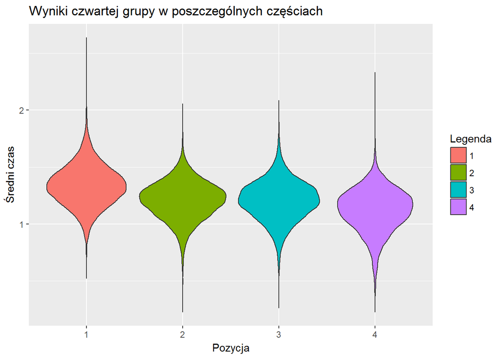

```r
ggplot(Dane_G4P, aes(x = as.character(Pozycja) , y = `mean(Czas)`, fill=as.character(Pozycja))) + labs(title="Wyniki czwartej grupy w poszczególnych częściach ",x="Pozycja", y = "Średni czas", fill="Legenda") + geom_violin()
```

##### Wykres pokazujący częstość grup dla poszczególnych krajow

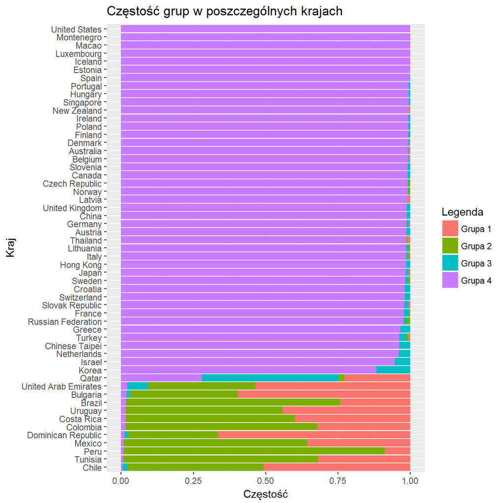

```r
Procent <- Dane %>% dplyr::group_by(Kraj) %>% dplyr::distinct(Szkola, nr)

Procenty <- Procent %>% dplyr::summarise(sum(nr=='grupa 1')/n(),sum(nr=='grupa 2')/n(),sum(nr=='grupa 3')/n(),sum(nr=='grupa 4')/n())


colnames(Procenty)<-c("Kraj","Grupa 1", "Grupa 2", "Grupa 3", "Grupa 4")
Procenty$Kraj<-factor(Procenty$Kraj, levels = Procenty$Kraj[order(Procenty$'Grupa 4')])
Pro <- gather(Procenty,grupa,procent,-Kraj)

ggplot(Pro, aes(x = Kraj, y=procent,fill=grupa)) +
geom_bar(position ="fill",stat = "identity") +
labs(title='Częstość grup w poszczególnych krajach', x='Kraj', y='Częstość', fill='Legenda') +
coord_flip()
```

##### W znacznej większości krajów przeważają kraje o szkołach **systematycznych**, czego można było się spodziewać, bowiem liczność tej grupy stanowiła grubo ponad połowę wszystkich grup. Jest też wiele krajów w których przeważają szkoły **słabsze**. Grupa **elitarnych** szkół nie występuje za często procentowo, co też jest wynikiem tego jak mało liczna jest ta grupa.

```r
library(rworldmap)

maksy<-max.col(Procenty[,-1])
maksy[maksy == 1] <- 'przeciętni'
maksy[maksy == 2] <- 'słabsi'
maksy[maksy == 3] <- 'elitarni'
maksy[maksy == 4] <- 'systematyczni'

Przewaga <- cbind(Procenty[,1], maksy)
colnames(Przewaga)<-c('Kraj','Najczęściej występująca grupa')

spdf <- joinCountryData2Map(Przewaga, joinCode="NAME", nameJoinColumn="Kraj", verbose = FALSE)
```

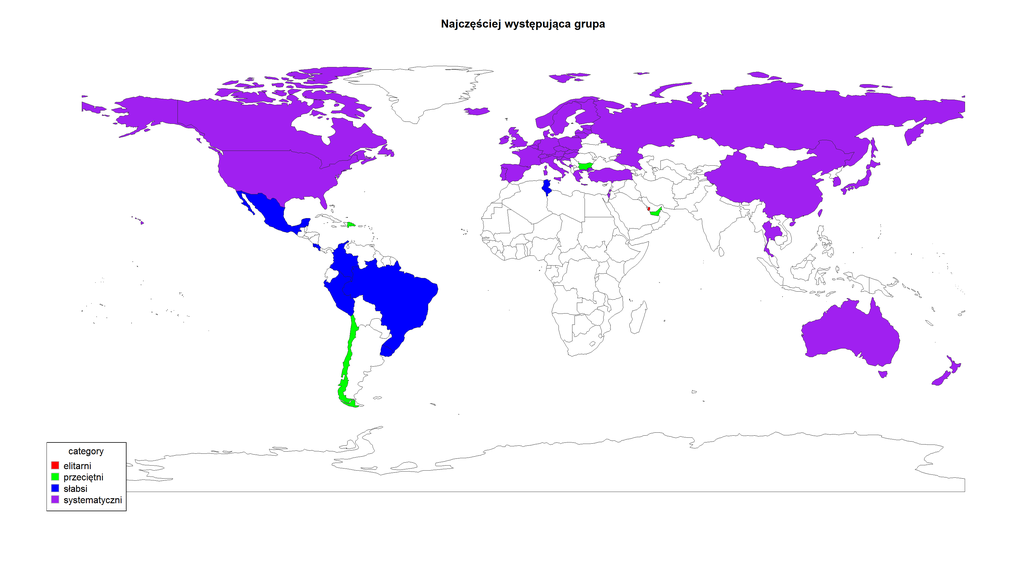

```r
mapCountryData(spdf, nameColumnToPlot='Najczęściej występująca grupa', catMethod="categorical", colourPalette=c('red', 'green', 'blue', 'purple'), borderCol='grey15')
```

##### Jak już stwierdziliśmy, znacząco przeważają szkoły **systematyczne**, głównie w krajach tak zwanego Zachodu, jak i w Chinach, Rosji i kilku mniejszych krajach azjatyckich. Kraje Ameryki Południowej mają przeważającą grupę szkół **słabszych**. Nieliczne kraje mają szkoły **przeciętne**, a tylko jeden kraj (Katar) ma szkoły **elitarne** jako przeważające.

##### Poniżej pokazujemy jakie są wyniki testu PISA dla części matematycznej:

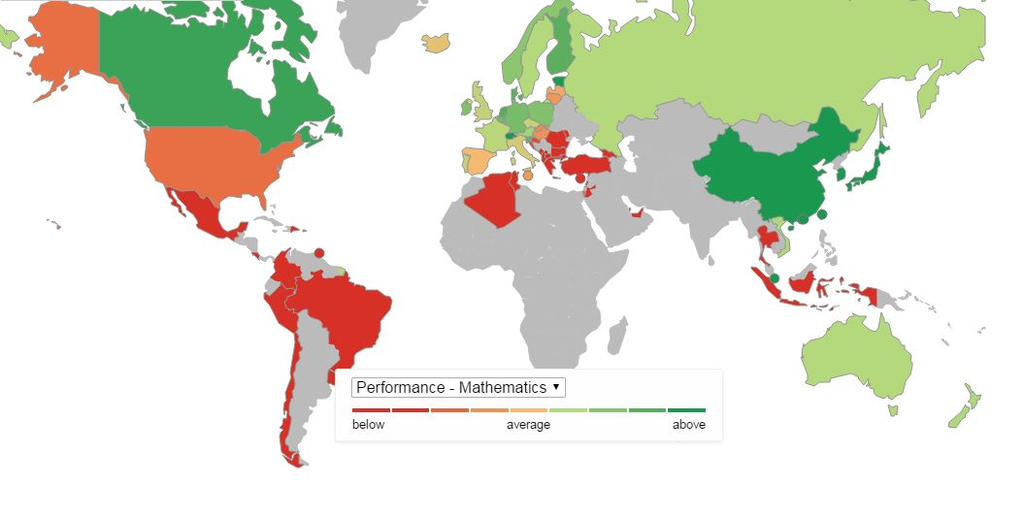

##### A tak prezentują się wyniki z czytania:

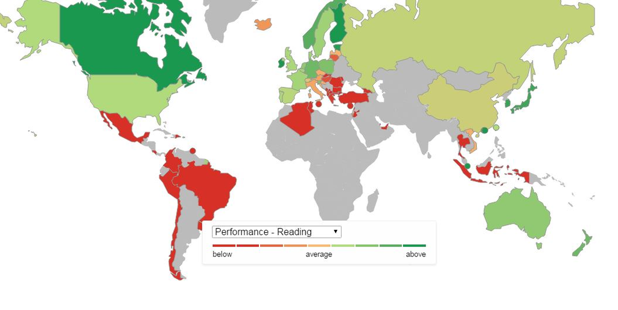

##### Wprowadzony przez nas podział na grupy szkół całkiem dobrze radzi sobie z różnicowaniem krajów ze względu na poziom szkolnictwa. Widać, że nazwa **słabsi** dla szkół, których studenci wolno rozwiązują zadania dobrze oddaje rzeczywistość w szczególności, gdy uwzględni się podane przez nas wykresy. Kraje, które osiągają satysfakcjonujące wyniki mają dużo systematycznych szkół, a te z dużą ilością szkół **systematycznych** i **elitarnych** faktycznie zasługują na te miana. Ciekawy jest przypadek Kataru, który, w zgodzie z podanym wcześniej diagramem, ma dużo zarówno **elitarnych**, **przeciętnych** jak i **systematycznych** szkół, a wyniki w tescie PISA ma bardzo słabe.

##### Na koniec zaprezentujemy jeszcze natężenia poszczególnych grup w krajach dla lepszego zobrazowania wyników.

##### Natężenie szkół **elitarnych** w krajach o ich częstym występowaniu:

```r
GR3 <- cbind(Procenty[,1], Procenty$`Grupa 3`)
colnames(GR3)<-c('Kraj', 'Elitarni')
GR3 <- GR3[GR3$Elitarni>0.02,]

spdf <- joinCountryData2Map(GR3, joinCode="NAME", nameJoinColumn="Kraj", verbose = FALSE)
```

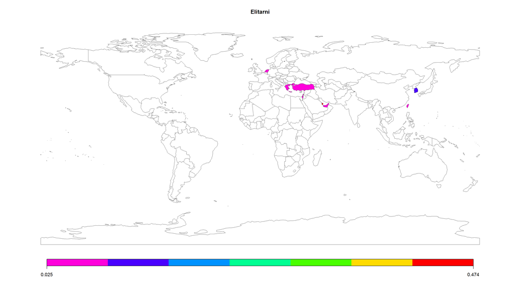

```r
mapCountryData(spdf, nameColumnToPlot="Elitarni", catMethod="fixedWidth", colourPalette='rainbow', borderCol='grey15')
```

##### Natężenie szkół **przeciętnych** w krajach o ich częstym występowaniu:

```r
GR1 <- cbind(Procenty[,1], Procenty$`Grupa 1`)
colnames(GR1)<-c('Kraj', 'Przecietni')
GR1 <- GR1[GR1$Przecietni>0.09,]

spdf <- joinCountryData2Map(GR1, joinCode="NAME", nameJoinColumn="Kraj", verbose = FALSE)
```

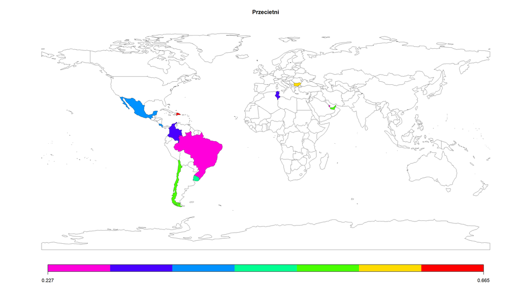

```r
mapCountryData(spdf, nameColumnToPlot="Przecietni", catMethod="fixedWidth", colourPalette='rainbow', borderCol='grey15')
```

##### Natężenie szkół **słabszych** w krajach o ich częstym występowaniu:

```r
GR2 <- cbind(Procenty[,1], Procenty$`Grupa 2`)
colnames(GR2)<-c('Kraj', 'Slabsi')
GR2 <- GR2[GR2$Slabsi>0.01,]

spdf <- joinCountryData2Map(GR2, joinCode="NAME", nameJoinColumn="Kraj",verbose=FALSE)
```

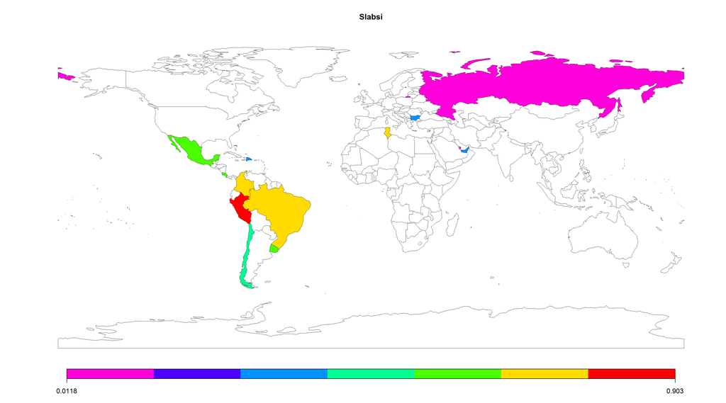

```r
mapCountryData(spdf, nameColumnToPlot="Slabsi", catMethod="fixedWidth", colourPalette='rainbow', borderCol='grey15')
```

##### Natężenie szkół **systematycznych** w krajach o ich częstym występowaniu:

```r
GR4 <- cbind(Procenty[,1], Procenty$`Grupa 4`)
colnames(GR4)<-c('Kraj', 'Systematyczni')
GR4 <- GR4[GR4$Systematyczni>0.8,]

spdf <- joinCountryData2Map(GR4, joinCode="NAME", nameJoinColumn="Kraj",verbose=FALSE)
```

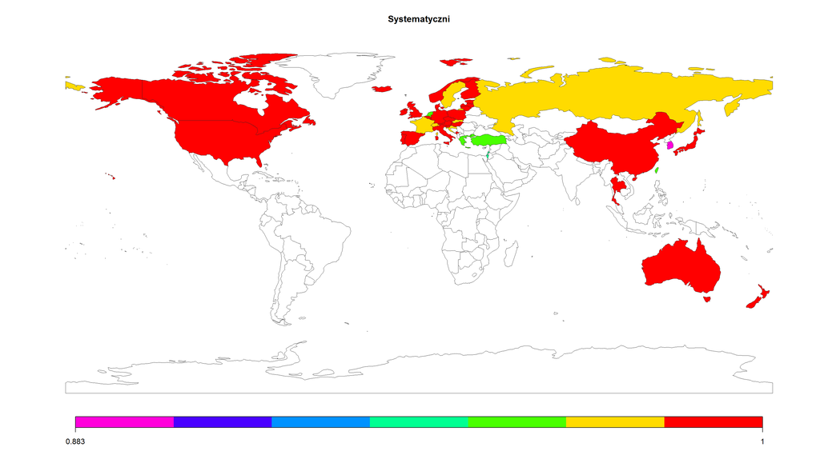

```r
mapCountryData(spdf, nameColumnToPlot="Systematyczni", catMethod="fixedWidth", colourPalette='rainbow', borderCol='grey15')
```